# Chapter 5 Forecasters Toolbox

Tyler George

Cornell College  
STA 364 Spring 2025 Block 5

# A tidy forecasting workflow

## Setup

```r
library(fpp3)
```

## A tidy forecasting workflow

The process of producing forecasts can be split up into a few fundamental steps.

1. Preparing data
2. Data visualization
3. Specifying a model
4. Model estimation
5. Accuracy & performance evaluation
6. Producing forecasts

## A tidy forecasting workflow

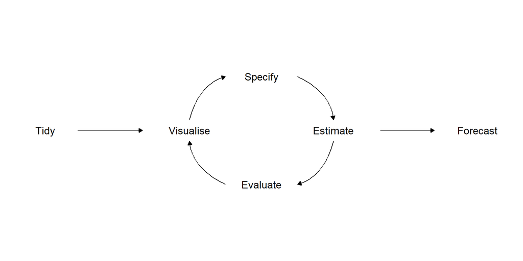

## Data preparation (tidy)

```r
gdppc <- global_economy |>
  mutate(GDP_per_capita = GDP/Population) |>
  select(Year, Country, GDP, Population, GDP_per_capita)
gdppc
```

```
# A tsibble: 15,150 x 5 [1Y]
# Key:       Country [263]
    Year Country             GDP Population GDP_per_capita
   <dbl> <fct>             <dbl>      <dbl>          <dbl>
 1  1960 Afghanistan  537777811.    8996351           59.8
 2  1961 Afghanistan  548888896.    9166764           59.9
 3  1962 Afghanistan  546666678.    9345868           58.5
 4  1963 Afghanistan  751111191.    9533954           78.8
 5  1964 Afghanistan  800000044.    9731361           82.2
 6  1965 Afghanistan 1006666638.    9938414          101.
 7  1966 Afghanistan 1399999967.   10152331          138.
 8  1967 Afghanistan 1673333418.   10372630          161.
 9  1968 Afghanistan 1373333367.   10604346          130.
10  1969 Afghanistan 1408888922.   10854428          130.
# ℹ 15,140 more rows
```

## Data visualisation

```r
gdppc |>
  filter(Country=="Sweden") |>
  autoplot(GDP_per_capita) +
    labs(title = "GDP per capita for Sweden", y = "$US")
```

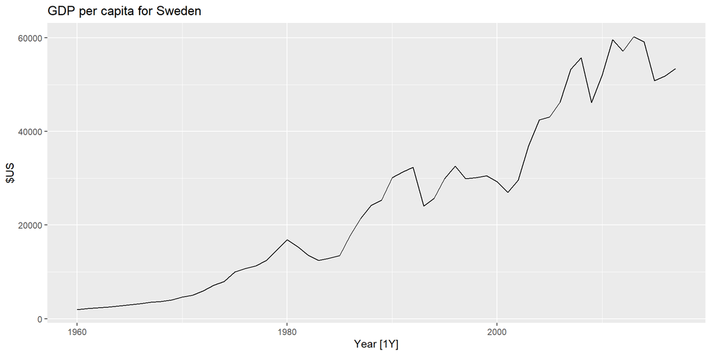

## Model estimation

The `model()` function trains models to data.

```r
fit <- gdppc |>
  model(trend_model = TSLM(GDP_per_capita ~ trend())) # TSLM to be covered later
fit |> head(5)
```

```
# A mable: 5 x 2
# Key:     Country [5]
  Country        trend_model
  <fct>              <model>
1 Afghanistan         <TSLM>
2 Albania             <TSLM>
3 Algeria             <TSLM>
4 American Samoa      <TSLM>
5 Andorra             <TSLM>
```

**Note**

## Producing forecasts

```r
fit |> forecast(h = "3 years")
```

```
# A fable: 789 x 5 [1Y]
# Key:     Country, .model [263]
   Country  .model  Year   GDP_per_capita
   <fct>    <chr>  <dbl>           <dist>
 1 Afghani… trend…  2018     N(526, 9653)
 2 Afghani… trend…  2019     N(534, 9689)
 3 Afghani… trend…  2020     N(542, 9727)
 4 Albania  trend…  2018  N(4716, 476419)
 5 Albania  trend…  2019  N(4867, 481086)
 6 Albania  trend…  2020  N(5018, 486012)
 7 Algeria  trend…  2018  N(4410, 643094)
 8 Algeria  trend…  2019  N(4489, 645311)
 9 Algeria  trend…  2020  N(4568, 647602)
10 America… trend…  2018 N(12491, 652926)
# ℹ 779 more rows
# ℹ 1 more variable: .mean <dbl>
```

**Note**

## Visualising forecasts

```r
fit |> forecast(h = "3 years") |>
  filter(Country=="Sweden") |>
  autoplot(gdppc) +
    labs(title = "GDP per capita for Sweden", y = "$US")
```

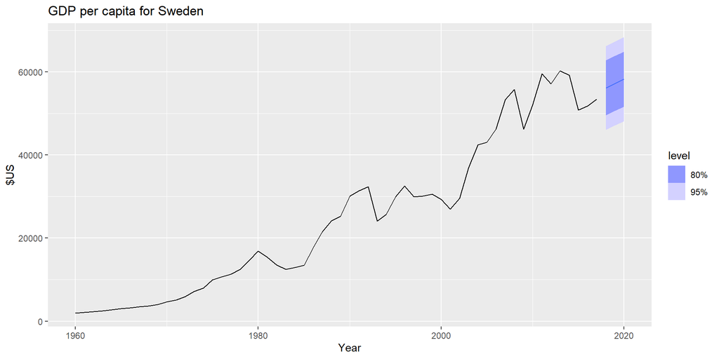

# Some simple forecasting methods

## `MEAN(y)`: Average method

- Forecast of all future values is equal to mean of historical data $\{y_1,\dots,y_T\}$.
- Forecasts: $\hat{y}_{T+h|T} = \bar{y} = (y_1+\dots+y_T)/T$

## `MEAN(y)`: Average method Plot

- Code
- Plot

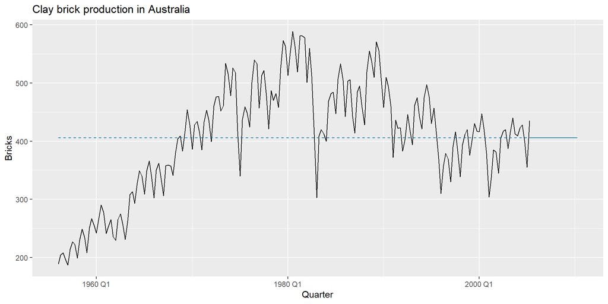

```r
bricks <- aus_production |>
  filter(!is.na(Bricks)) |>
  mutate(average = mean(Bricks))

fc <- bricks |>
  filter(row_number() == n()) |> as_tibble() |>
  unnest(Quarter = list(as.Date(Quarter) + months(c(0, 12*5))))

bricks |>
  ggplot(aes(x = Quarter, y = Bricks)) +
  geom_line() +
  geom_line(aes(y = average), colour = "#0072B2", linetype = "dashed") +
  geom_line(aes(y = average), data = fc, colour = "#0072B2") +
  labs(title = "Clay brick production in Australia")
```

## `NAIVE(y)`: Naïve method

- Forecasts equal to last observed value.
- Forecasts: $\hat{y}_{T+h|T} =y_T$.
- Consequence of efficient market hypothesis.
- Code
- Plot

```r
bricks |>
  filter(!is.na(Bricks)) |>
  model(NAIVE(Bricks)) |>
  forecast(h = "5 years") |>
  autoplot(filter(bricks, year(Quarter) > 1990), level = NULL) +
    geom_point(data = slice(bricks, n()), aes(y=Bricks), colour = "#0072B2") +
    labs(title = "Clay brick production in Australia")
```

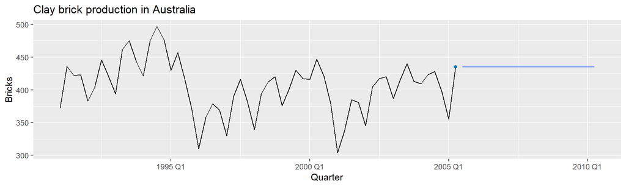

## `SNAIVE(y ~ lag(m))`: Seasonal naïve method

- Forecasts equal to last value from same season.
- Forecasts: $\hat{y}_{T+h|T} =y_{T+h-m(k+1)}$, where $m=$ seasonal period and $k$ is the integer part of $(h-1)/m$.
- Code
- Plot

```r
bricks |>
  model(SNAIVE(Bricks ~ lag("year"))) |>
  forecast(h = "5 years") |>
  autoplot(filter(bricks, year(Quarter) > 1990), level = NULL) +
  geom_point(data = slice(bricks, (n()-3):n()), aes(y=Bricks), colour = "#0072B2") +
  labs(title = "Clay brick production in Australia")
```

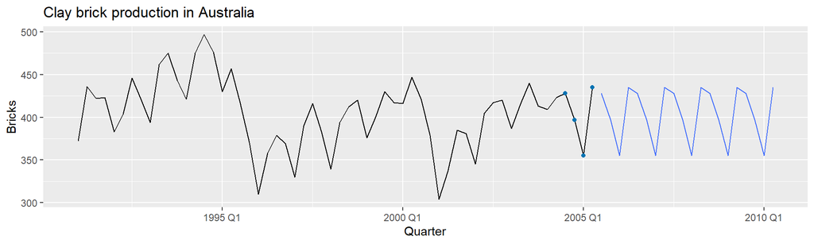

## `RW(y ~ drift())`: Drift method

- Definition
- Code & Plot
- Forecasts equal to last value plus average change.
- Forecasts:

$$\begin{align*}
\hat{y}_{T+h|T} & = y_{T} + \frac{h}{T-1}\sum_{t=2}^T (y_t-y_{t-1})\\
& = y_T + \frac{h}{T-1}(y_T -y_1).
\end{align*}$$

- Equivalent to extrapolating a line drawn between first and last observations.

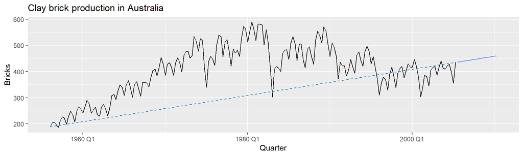

```r
aus_production |>
  filter(!is.na(Bricks)) |>
  model(RW(Bricks ~ drift())) |>
  forecast(h = "5 years") |>
  autoplot(aus_production, level = NULL) +
  geom_line(data = slice(aus_production, range(cumsum(!is.na(Bricks)))),
            aes(y=Bricks), linetype = "dashed", colour = "#0072B2") +
  labs(title = "Clay brick production in Australia")
```

## Model fitting

The `model()` function trains models to data.

```r
brick_fit <-  aus_production |>
  filter(!is.na(Bricks)) |>
  model(
    Seasonal_naive = SNAIVE(Bricks),
    Naive = NAIVE(Bricks),
    Drift = RW(Bricks ~ drift()),
    Mean = MEAN(Bricks)
  )
```

```
# A mable: 1 x 4
  Seasonal_naive   Naive         Drift    Mean
         <model> <model>       <model> <model>
1       <SNAIVE> <NAIVE> <RW w/ drift>  <MEAN>
```

## Producing forecasts

```r
brick_fc <- brick_fit |>
  forecast(h = "5 years")
```

```
# A fable: 80 x 4 [1Q]
# Key:     .model [4]
  .model   Quarter       Bricks .mean
  <chr>      <qtr>       <dist> <dbl>
1 Seasona… 2005 Q3 N(428, 2336)   428
2 Seasona… 2005 Q4 N(397, 2336)   397
3 Seasona… 2006 Q1 N(355, 2336)   355
4 Seasona… 2006 Q2 N(435, 2336)   435
# ℹ 76 more rows
```

## Visualising forecasts

```r
brick_fc |>
  autoplot(aus_production, level = NULL) +
  labs(title = "Clay brick production in Australia",
       y = "Millions of bricks") +
  guides(colour = guide_legend(title = "Forecast"))
```

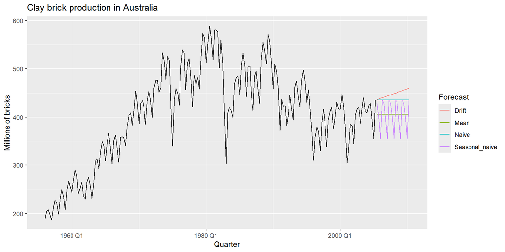

## Facebook closing stock price

- Code
- Plot

```r
# Extract training data
fb_stock <- gafa_stock |>
  filter(Symbol == "FB") |>
  mutate(trading_day = row_number()) |>
  update_tsibble(index=trading_day, regular=TRUE)

# Specify, estimate and forecast
fb_stock |>
  model(
    Mean = MEAN(Close),
    Naive = NAIVE(Close),
    Drift = RW(Close ~ drift())
  ) |>
  forecast(h=42) |>
  autoplot(fb_stock, level = NULL) +
  labs(title = "Facebook closing stock price", y="$US") +
  guides(colour=guide_legend(title="Forecast"))
```

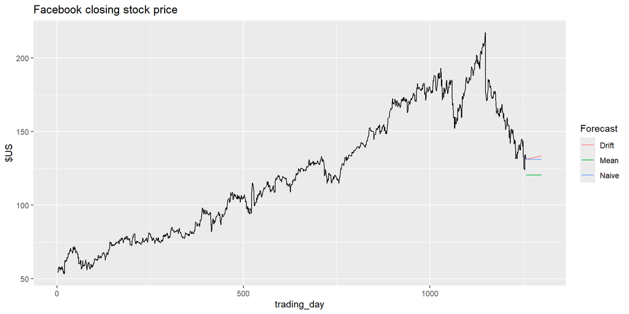

## Your turn

- Produce forecasts using an appropriate benchmark method for household wealth (`hh_budget`). Plot the results using `autoplot()`.
- Produce forecasts using an appropriate benchmark method for Australian takeaway food turnover (`aus_retail`). Plot the results using `autoplot()`.

# Residual diagnostics

## Fitted values

- $\hat{y}_{t|t-1}$ is the forecast of $y_t$ based on observations $y_1,\dots,y_{t-1}$.
- We call these “fitted values”.
- Sometimes drop the subscript: $\hat{y}_t \equiv \hat{y}_{t|t-1}$.
- Often not true forecasts since parameters are estimated on all data.

*For example:*

- $\hat{y}_{t} = \bar{y}$ for average method.
- $\hat{y}_{t} = y_{t-1} + (y_{T}-y_1)/(T-1)$ for drift method.

## Forecasting residuals

*Residuals in forecasting:* difference between observed value and its fitted value: $e_t = y_t-\hat{y}_{t|t-1}$.

**Assumptions**

1. $\{e_t\}$ uncorrelated. If they aren’t, then information left in residuals that should be used in computing forecasts.
2. $\{e_t\}$ have mean zero. If they don’t, then forecasts are biased.

**Useful properties** (for distributions & prediction intervals)

3. $\{e_t\}$ have constant variance.
4. $\{e_t\}$ are normally distributed.

## Facebook closing stock price

```r
fb_stock |> autoplot(Close)
```

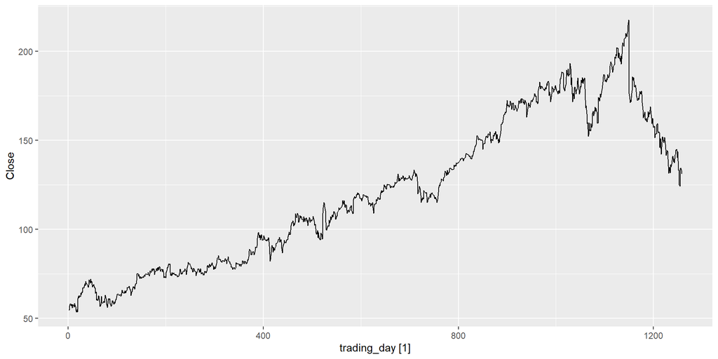

## Facebook closing stock price

```r
fit <- fb_stock |> model(NAIVE(Close))
augment(fit) |> head(5)
```

```
# A tsibble: 5 x 7 [1]
# Key:       Symbol, .model [1]
  Symbol .model       trading_day Close .fitted .resid .innov
  <chr>  <chr>              <int> <dbl>   <dbl>  <dbl>  <dbl>
1 FB     NAIVE(Close)           1  54.7    NA   NA     NA
2 FB     NAIVE(Close)           2  54.6    54.7 -0.150 -0.150
3 FB     NAIVE(Close)           3  57.2    54.6  2.64   2.64
4 FB     NAIVE(Close)           4  57.9    57.2  0.720  0.720
5 FB     NAIVE(Close)           5  58.2    57.9  0.310  0.310
```

Naive forecasts:

$\hat{y}_{t|t-1} = y_{t-1}$

$e_t = y_t - \hat{y}_{t|t-1} = y_t-y_{t-1}$

Where .fitted = $\hat{y}_{t|t-1}$ and .resid = $\phantom{\hat{y}_{|}}{e}_{t}\phantom{\hat{y}_{|}}$

## Facebook closing stock price

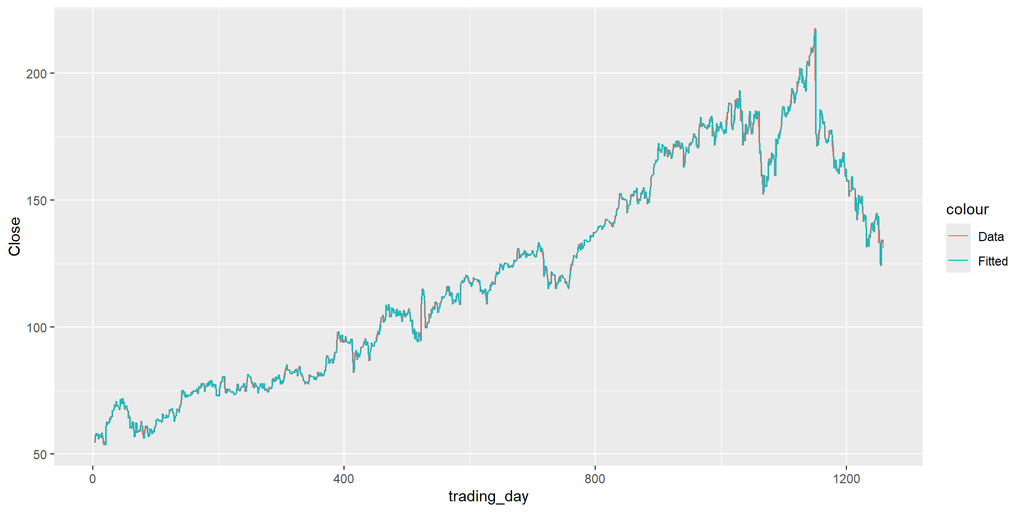

```r
augment(fit) |>
  ggplot(aes(x = trading_day)) +
  geom_line(aes(y = Close, colour = "Data")) +
  geom_line(aes(y = .fitted, colour = "Fitted"))
```

## Facebook closing stock price

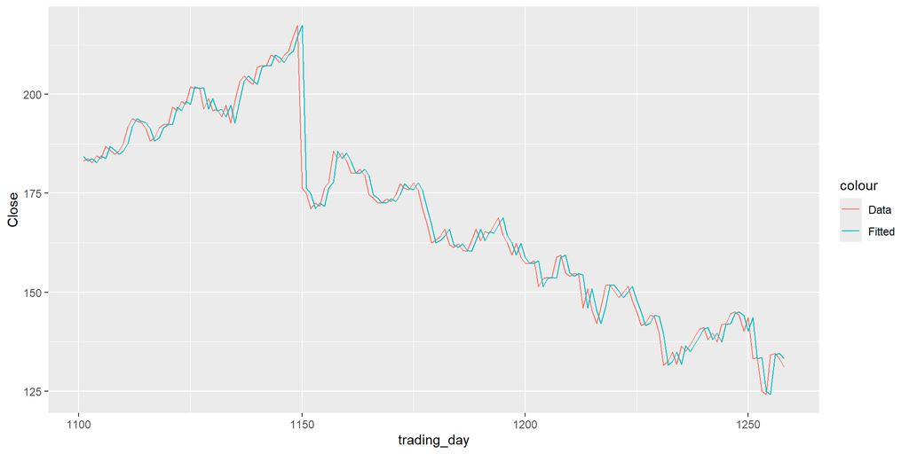

```r
augment(fit) |>
  filter(trading_day > 1100) |>
  ggplot(aes(x = trading_day)) +
  geom_line(aes(y = Close, colour = "Data")) +
  geom_line(aes(y = .fitted, colour = "Fitted"))
```

## Facebook closing stock price

```r
augment(fit) |>
  autoplot(.resid) +
  labs(y = "$US",
       title = "Residuals from naïve method")
```

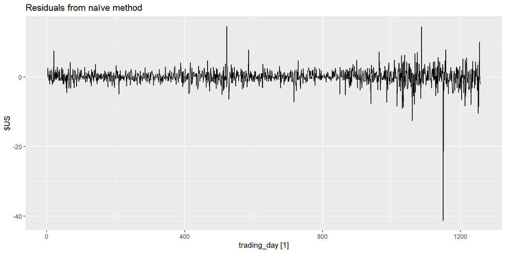

## Facebook closing stock price

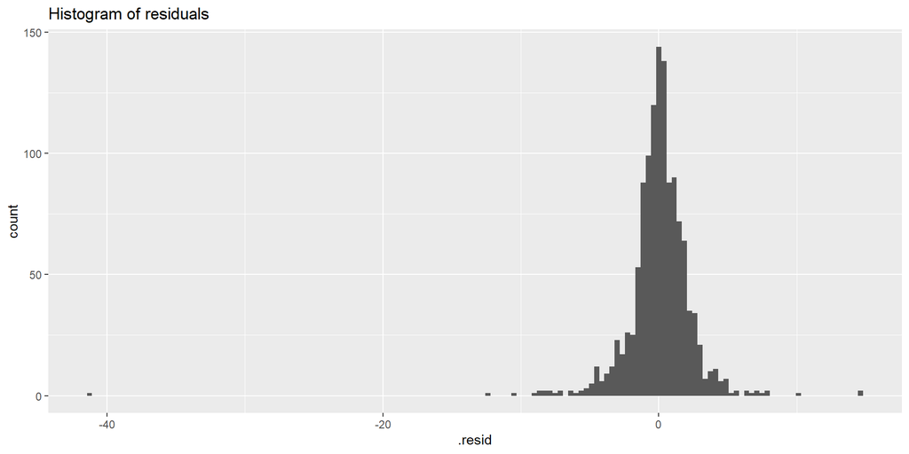

```r
augment(fit) |>
  ggplot(aes(x = .resid)) +
  geom_histogram(bins = 150) +
  labs(title = "Histogram of residuals")
```

## Facebook closing stock price

```r
augment(fit) |>
  ACF(.resid) |>
  autoplot() + labs(title = "ACF of residuals")
```

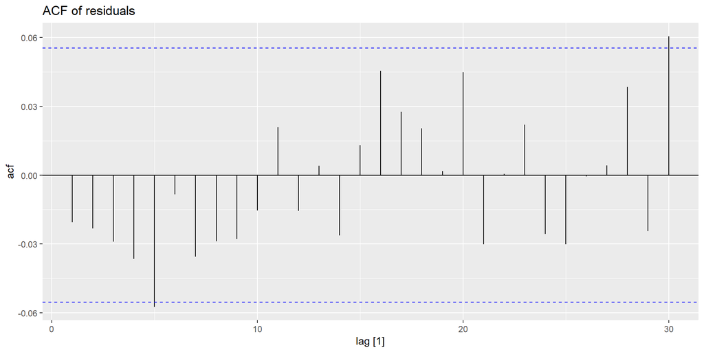

## `gg_tsresiduals()` function

```r
gg_tsresiduals(fit)
```

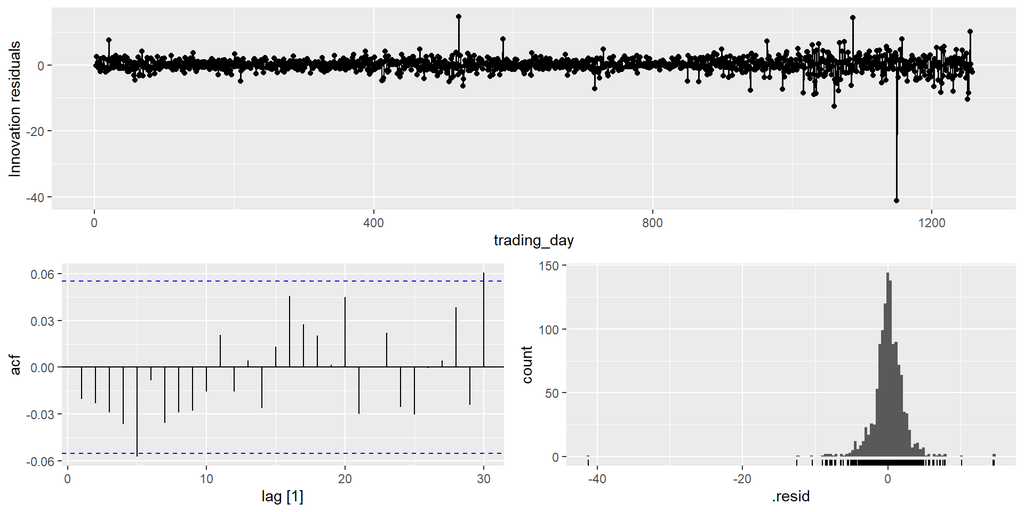

## ACF of residuals

- We assume that the residuals are white noise (uncorrelated, mean zero, constant variance). If they aren’t, then there is information left in the residuals that should be used in computing forecasts.
- So a standard residual diagnostic is to check the ACF of the residuals of a forecasting method.
- We *expect* these to look like white noise.

## Portmanteau tests: Box-Pierce test

$r_k =$ autocorrelation of residual at lag $k$

Consider a *whole set* of $r_{k}$ values, and develop a test to see whether the set is significantly different from a zero set.

**Box-Pierce test**
$$Q = T \sum_{k=1}^\ell r_k^2$$
where $\ell$ is max lag being considered and $T$ is number of observations.

- If each $r_k$ close to zero, $Q$ will be **small**.
- If some $r_k$ values large (positive or negative), $Q$ will be **large**.

## Portmanteau tests: Ljung-Box test (more accurate) (1/2)

$r_k =$ autocorrelation of residual at lag $k$

Consider a *whole set* of $r_{k}$ values, and develop a test to see whether the set is significantly different from a zero set.

## Portmanteau tests: Ljung-Box test (more accurate) (2/2)

- If each $r_k$ close to zero, $Q^*$ will be **small**.
- If some $r_k$ values large (positive or negative), $Q$ will be **large**.
- Use $\ell=10$ for non-seasonal data, $\ell=2m$ for seasonal data (where $m$ is seasonal period).
- Better performance, especially in small samples. Test is not good when $\ell$ is large, so if these values are larger than $T/5$, then use $\ell=T/5$
- How large is too large?

## Portmanteau tests

- If data are WN, $Q$ and $Q^*$ have $\chi^2$ distribution with $\ell$ degrees of freedom.
- `lag` $= \ell$

```r
augment(fit) |>
  features(.resid, box_pierce, lag=10)
```

```
# A tibble: 1 × 4
  Symbol .model       bp_stat bp_pvalue
  <chr>  <chr>          <dbl>     <dbl>
1 FB     NAIVE(Close)    12.1     0.281
```

```r
augment(fit) |>
  features(.resid, ljung_box, lag=10)
```

```
# A tibble: 1 × 4
  Symbol .model       lb_stat lb_pvalue
  <chr>  <chr>          <dbl>     <dbl>
1 FB     NAIVE(Close)    12.1     0.276
```

# Distributional forecasts and prediction intervals

## Forecast distributions

- A forecast $\hat{y}_{T+h|T}$ is (usually) the mean of the conditional distribution $y_{T+h} \mid y_1, \dots, y_{T}$.
- Most time series models produce normally distributed forecasts.
- The forecast distribution describes the probability of observing any future value.

## Forecast distributions

Assuming residuals are normal, uncorrelated, sd = $\hat\sigma$:

| Method | Forecast Distribution |
| --- | --- |
| Mean: | $y_{T+h\\|T} \sim N(\bar{y}, (1 + 1/T)\hat{\sigma}^2)$ |
| Naïve: | $y_{T+h\\|T} \sim N(y_T, h\hat{\sigma}^2)$ |
| Seasonal naïve: | $y_{T+h\\|T} \sim N(y_{T+h-m(k+1)}, (k+1)\hat{\sigma}^2)$ |
| Drift: | $y_{T+h\\|T} \sim N(y_T + \frac{h}{T-1}(y_T - y_1),h\frac{T+h}{T}\hat{\sigma}^2)$ |

where $k$ is the integer part of $(h-1)/m$.

**Note**

When $h=1$ and $T$ is large, these all give the same approximate forecast variance: $\hat{\sigma}^2$.

## Prediction intervals

- A prediction interval gives a region within which we expect $y_{T+h}$ to lie with a specified probability.
- Assuming forecast errors are normally distributed, then a 95% PI is

$$\hat{y}_{T+h|T} \pm 1.96 \hat\sigma_h$$

where $\hat\sigma_h$ is the st dev of the $h$-step distribution.

**Note**

When $h=1$, $\hat\sigma_h$ can be estimated from the residuals.

## Prediction intervals

```r
brick_fc |> hilo(level = 95)
```

```
# A tsibble: 80 x 5 [1Q]
# Key:       .model [4]
   .model  Quarter       Bricks .mean
   <chr>     <qtr>       <dist> <dbl>
 1 Season… 2005 Q3 N(428, 2336)   428
 2 Season… 2005 Q4 N(397, 2336)   397
 3 Season… 2006 Q1 N(355, 2336)   355
 4 Season… 2006 Q2 N(435, 2336)   435
 5 Season… 2006 Q3 N(428, 4672)   428
 6 Season… 2006 Q4 N(397, 4672)   397
 7 Season… 2007 Q1 N(355, 4672)   355
 8 Season… 2007 Q2 N(435, 4672)   435
 9 Season… 2007 Q3 N(428, 7008)   428
10 Season… 2007 Q4 N(397, 7008)   397
# ℹ 70 more rows
# ℹ 1 more variable: `95%` <hilo>
```

## Prediction intervals

- Point forecasts often useless without a measure of uncertainty (such as prediction intervals).
- Prediction intervals require a stochastic model (with random errors, etc).
- For most models, prediction intervals get wider as the forecast horizon increases.
- Use `level` argument to control coverage.
- Check residual assumptions before believing them.
- Usually too narrow due to unaccounted uncertainty.

# Forecasting with transformations

## Modelling with transformations

```r
eggs <- prices |>
  filter(!is.na(eggs)) |> select(eggs)
eggs |> autoplot() +
  labs(title="Annual egg prices",
       y="$US (adjusted for inflation)")
```

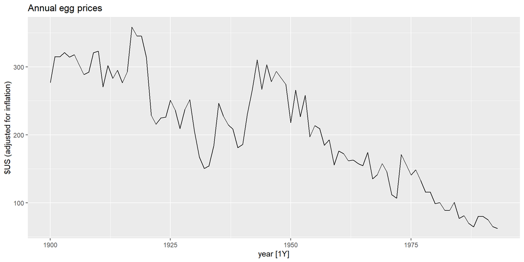

## Modelling with transformations

Transformations used in the left of the formula will be automatically back-transformed. To model log-transformed egg prices, you could use:

```r
fit <- eggs |>
  model(RW(log(eggs) ~ drift()))
fit
```

```
# A mable: 1 x 1
  `RW(log(eggs) ~ drift())`
                    <model>
1             <RW w/ drift>
```

## Forecasting with transformations

```r
fc <- fit |>
  forecast(h = 50)
fc
```

```
# A fable: 50 x 4 [1Y]
# Key:     .model [1]
   .model                   year             eggs .mean
   <chr>                   <dbl>           <dist> <dbl>
 1 RW(log(eggs) ~ drift())  1994 t(N(4.1, 0.018))  61.8
 2 RW(log(eggs) ~ drift())  1995 t(N(4.1, 0.036))  61.4
 3 RW(log(eggs) ~ drift())  1996 t(N(4.1, 0.055))  61.0
 4 RW(log(eggs) ~ drift())  1997 t(N(4.1, 0.074))  60.6
 5 RW(log(eggs) ~ drift())  1998 t(N(4.1, 0.093))  60.2
 6 RW(log(eggs) ~ drift())  1999    t(N(4, 0.11))  59.8
 7 RW(log(eggs) ~ drift())  2000    t(N(4, 0.13))  59.4
 8 RW(log(eggs) ~ drift())  2001    t(N(4, 0.15))  59.0
 9 RW(log(eggs) ~ drift())  2002    t(N(4, 0.18))  58.6
10 RW(log(eggs) ~ drift())  2003     t(N(4, 0.2))  58.3
# ℹ 40 more rows
```

## Forecasting with transformations

```r
fc |> autoplot(eggs) +
  labs(title="Annual egg prices",
       y="US$ (adjusted for inflation)")
```

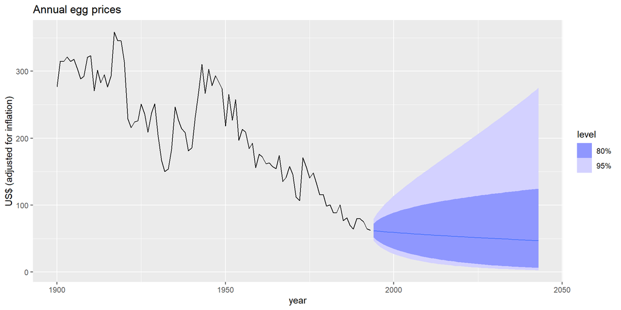

## Bias adjustment

- Back-transformed point forecasts are medians.
- Back-transformed PI have the correct coverage.

**Back-transformed means (if you are math inclined)**

Let $X$ be have mean $\mu$ and variance $\sigma^2$.

Let $f(x)$ be back-transformation function, and $Y=f(X)$.

Taylor series expansion about $\mu$:
$$f(X) = f(\mu) + (X-\mu)f'(\mu) + \frac{1}{2}(X-\mu)^2f''(\mu).$$

**Note**

$E[Y] = E[f(X)] = f(\mu) + \frac12 \sigma^2 f''(\mu)$

## Bias adjustment

**Box-Cox back-transformation (if math inclined):**
$$\begin{align*}
y_t &= \left\{\begin{array}{ll}
\exp(w_t) & \quad \lambda = 0; \\
(\lambda W_t+1)^{1/\lambda} & \quad \lambda \ne 0.
\end{array}\right. \\
f(x) &= \begin{cases}
e^x & \quad\lambda=0;\\
(\lambda x + 1)^{1/\lambda} & \quad\lambda\ne0.
\end{cases}\\
f''(x) &= \begin{cases}
e^x & \quad\lambda=0;\\
(1-\lambda)(\lambda x + 1)^{1/\lambda-2} & \quad\lambda\ne0.
\end{cases}
\end{align*}$$

**Note**

$E[Y] = \begin{cases} e^\mu\left[1+\frac{\sigma^2}{2}\right] & \quad\lambda=0;\\ (\lambda \mu + 1)^{1/\lambda}\left[1+\frac{\sigma^2(1-\lambda)}{2(\lambda\mu+1)^2}\right] & \quad\lambda\ne0. \end{cases}$

## Bias adjustment

```r
fc |>
  autoplot(eggs, level = 80, point_forecast = lst(mean, median)) +
  labs(title="Annual egg prices",
       y="US$ (adjusted for inflation)")
```

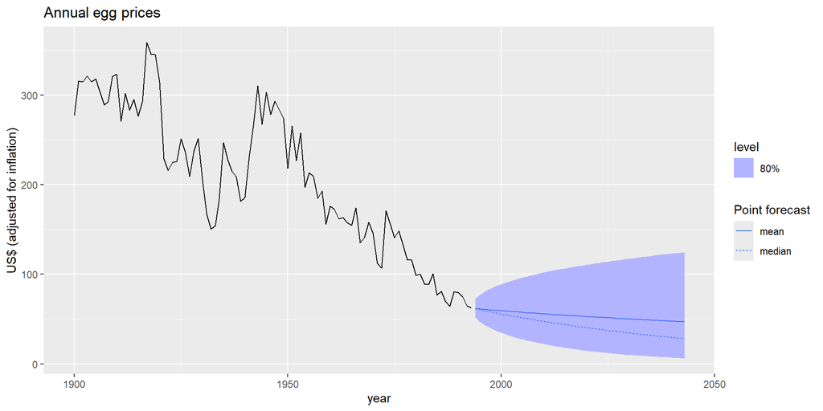

# Forecasting and decomposition

## Forecasting and decomposition

$$y_t = \hat{S}_t + \hat{A}_t$$

- $\hat{A}_t$ is seasonally adjusted component
- $\hat{S}_t$ is seasonal component.
  - Forecast $\hat{S}_t$ using SNAIVE.
  - Forecast $\hat{A}_t$ using non-seasonal time series method.
  - Combine forecasts of $\hat{S}_t$ and $\hat{A}_t$ to get forecasts of original data.

## US Retail Employment

```r
us_retail_employment <- us_employment |>
  filter(year(Month) >= 1990, Title == "Retail Trade") |>
  select(-Series_ID)
us_retail_employment
```

```
# A tsibble: 357 x 3 [1M]
      Month Title        Employed
      <mth> <chr>           <dbl>
 1 1990 Jan Retail Trade   13256.
 2 1990 Feb Retail Trade   12966.
 3 1990 Mar Retail Trade   12938.
 4 1990 Apr Retail Trade   13012.
 5 1990 May Retail Trade   13108.
 6 1990 Jun Retail Trade   13183.
 7 1990 Jul Retail Trade   13170.
 8 1990 Aug Retail Trade   13160.
 9 1990 Sep Retail Trade   13113.
10 1990 Oct Retail Trade   13185.
# ℹ 347 more rows
```

## US Retail Employment

```r
dcmp <- us_retail_employment |>
  model(STL(Employed)) |>
  components() |> select(-.model)
dcmp
```

```
# A tsibble: 357 x 6 [1M]
      Month Employed  trend season_year remainder season_adjust
      <mth>    <dbl>  <dbl>       <dbl>     <dbl>         <dbl>
 1 1990 Jan   13256. 13288.      -33.0      0.836        13289.
 2 1990 Feb   12966. 13269.     -258.     -44.6          13224.
 3 1990 Mar   12938. 13250.     -290.     -22.1          13228.
 4 1990 Apr   13012. 13231.     -220.       1.05         13232.
 5 1990 May   13108. 13211.     -114.      11.3          13223.
 6 1990 Jun   13183. 13192.      -24.3     15.5          13207.
 7 1990 Jul   13170. 13172.      -23.2     21.6          13193.
 8 1990 Aug   13160. 13151.       -9.52    17.8          13169.
 9 1990 Sep   13113. 13131.      -39.5     22.0          13153.
10 1990 Oct   13185. 13110.       61.6     13.2          13124.
# ℹ 347 more rows
```

## US Retail Employment

```r
dcmp_forecast<- dcmp |>
                model(NAIVE(season_adjust)) |>
                forecast()

  autoplot(dcmp_forecast,dcmp) +
  labs(title = "Naive forecasts of seasonally adjusted data")
```

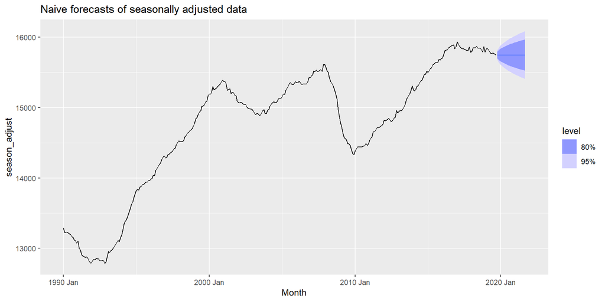

## US Retail Employment

```r
us_retail_employment |>
  model(stlf = decomposition_model(
    STL(Employed ~ trend(window = 7), robust = TRUE),
    NAIVE(season_adjust)
  )) |>
  forecast() |>
  autoplot(us_retail_employment)
```

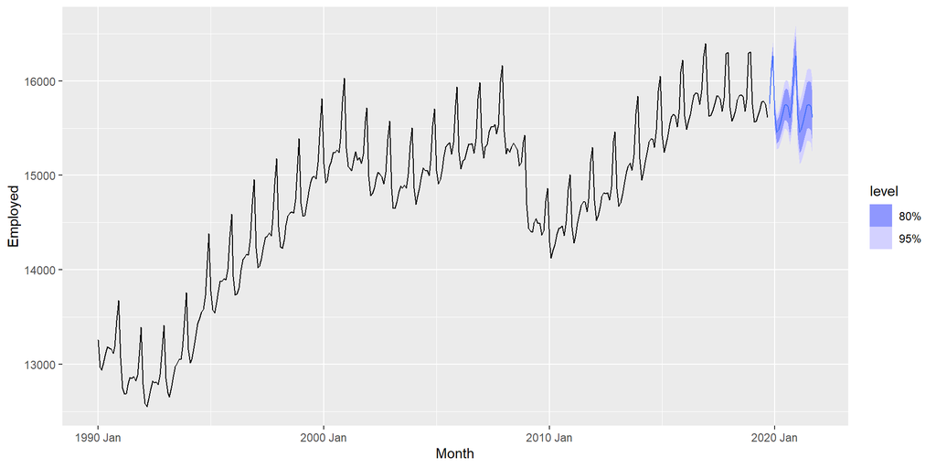

## Decomposition models

`decomposition_model()` creates a decomposition model

- You must provide a method for forecasting the `season_adjust` series.
- A seasonal naive method is used by default for the `seasonal` components.
- The variances from both the seasonally adjusted and seasonal forecasts are combined.

# Evaluating forecast accuracy

## Training and test sets (1/2)

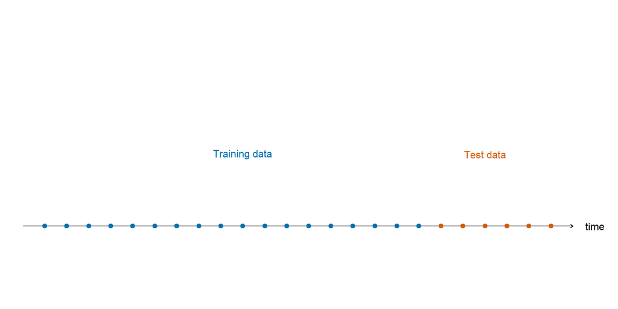

## Training and test sets (2/2)

- A model which fits the training data well will not necessarily forecast well.
- A perfect fit can always be obtained by using a model with enough parameters.
- Over-fitting a model to data is just as bad as failing to identify a systematic pattern in the data.
- **The test set must not be used for *any* aspect of model development or calculation of forecasts.**
- Forecast accuracy is based only on the test set.

## Forecast errors

Forecast “error”: the difference between an observed value and its forecast.
$$e_{T+h} = y_{T+h} - \hat{y}_{T+h|T},$$
where the training data is given by $\{y_1,\dots,y_T\}$

- Unlike residuals, forecast errors on the test set involve multi-step forecasts.
- These are *true* forecast errors as the test data is not used in computing $\hat{y}_{T+h|T}$.

## Measures of forecast accuracy

- Code
- Plot

```r
train <- aus_production |>
  filter(between(year(Quarter), 1992, 2007))
beer <- aus_production |>
  filter(year(Quarter) >= 1992)
beer_fc_plot <- train |>
  model(
    Mean = MEAN(Beer),
    Naive = NAIVE(Beer),
    Seasonal_naive = SNAIVE(Beer),
    Drift = RW(Beer ~ drift())
  ) |>
  forecast(h=11) |>
  autoplot(beer, level = NULL) +
    labs(title = "Forecasts for quarterly beer production",
         y = "Megalitres") +
    guides(colour=guide_legend(title="Forecast"))
beer_fc_plot
```

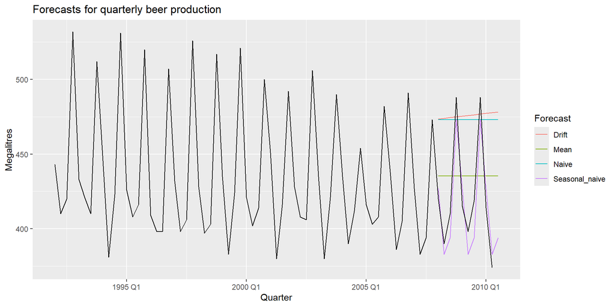

## Measures of forecast accuracy

$y_{T+h}= (T+h)$th observation, $h=1,\dots,H$

$\hat{y}_{T+h|T}=$ its forecast based on data up to time $T$.

$e_{T+h} = y_{T+h} - \hat{y}_{{T+h}|{T}}$

| Name | Abb. | Formula |
| --- | --- | --- |
| Mean Abosolue Error | MAE | $\text{mean}(\\|e_{T+h}\\|)$ |
| Mean Squared Error | MSE | $\text{mean}(e_{T+h}^2)$ |
| Root MSE | RMSE | $\sqrt{\text{mean}(e_{T+h}^2)$ |
| Mean Absolute Percent Error | MAPE | $100\text{mean}(\\|e_{T+h}\\|/ \\|y_{T+h}\\|)$ |

- MAE, MSE, RMSE are all scale dependent.
- MAPE is scale independent but is only sensible if $y_t\gg 0$ for all $t$, and $y$ has a natural zero.

## Mean Absolute Scaled Error (non-seasonal)

$$\text{MASE} = \text{mean}(|e_{T+h}|/Q)$$

where $Q$ is a stable measure of the scale of the time series $\{y_t\}$.

Proposed by Hyndman and Koehler (IJF, 2006).

For non-seasonal time series,

$$Q = (T-1)^{-1}\sum_{t=2}^T |y_t-y_{t-1}|$$
works well. Then MASE is equivalent to MAE relative to a naïve method.

## Mean Absolute Scaled Error (seasonal)

$$\text{MASE} = \text{mean}(|e_{T+h}|/Q)$$

where $Q$ is a stable measure of the scale of the time series $\{y_t\}$.

Proposed by Hyndman and Koehler (IJF, 2006).

For seasonal time series,
$$Q = (T-m)^{-1}\sum_{t=m+1}^T |y_t-y_{t-m}|$$
works well. Then MASE is equivalent to MAE relative to a seasonal naïve method.

## Measures of forecast accuracy: Time Series

```r
beer_fc_plot
```

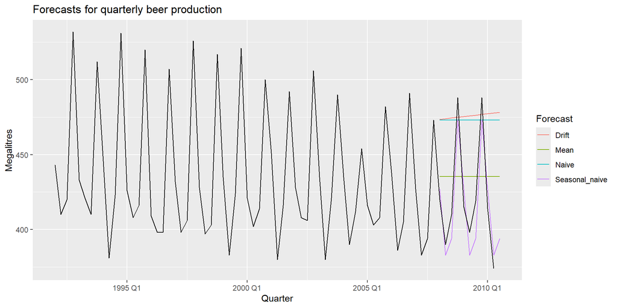

## Measures of forecast accuracy: Model Fits

```r
recent_production <- aus_production |>
  filter(year(Quarter) >= 1992)
train <- recent_production |>
  filter(year(Quarter) <= 2007)
beer_fit <- train |>
  model(
    Mean = MEAN(Beer),
    Naive = NAIVE(Beer),
    Seasonal_naive = SNAIVE(Beer),
    Drift = RW(Beer ~ drift())
  )
beer_fc <- beer_fit |>
  forecast(h = 10)
```

## Measures of forecast accuracy: On Training data (1/2)

- Smaller is better
- Use to evaluate models individually (based on training data, overfitting possible)

```r
accuracy(beer_fit)
```

```
# A tibble: 4 × 10
  .model         .type           ME  RMSE   MAE    MPE  MAPE  MASE RMSSE   ACF1
  <chr>          <chr>        <dbl> <dbl> <dbl>  <dbl> <dbl> <dbl> <dbl>  <dbl>
1 Mean           Training  0         43.6  35.2 -0.937  7.89  2.46  2.60 -0.109
2 Naive          Training  4.76e- 1  65.3  54.7 -0.916 12.2   3.83  3.89 -0.241
3 Seasonal_naive Training -2.13e+ 0  16.8  14.3 -0.554  3.31  1     1    -0.288
4 Drift          Training -5.41e-15  65.3  54.8 -1.03  12.2   3.83  3.89 -0.241
```

## Measures of forecast accuracy: On Training data (2/2)

```r
accuracy(beer_fit) |>
  arrange(.model) |> # Sorts model names alphabetically
  select(.model, .type, RMSE, MAE, MAPE, MASE) #The metrics we defined
```

```
# A tibble: 4 × 6
  .model         .type     RMSE   MAE  MAPE  MASE
  <chr>          <chr>    <dbl> <dbl> <dbl> <dbl>
1 Drift          Training  65.3  54.8 12.2   3.83
2 Mean           Training  43.6  35.2  7.89  2.46
3 Naive          Training  65.3  54.7 12.2   3.83
4 Seasonal_naive Training  16.8  14.3  3.31  1
```

## Measures of forecast accuracy: On Testing data

- Smaller is better
- Can be used to compare models and evaluate models individually
- Gives a realistic expectation of error if we rebuild model on all data for future forecasts

```r
accuracy(beer_fc, recent_production) |>
  arrange(.model) |>
  select(.model, .type, RMSE, MAE, MAPE, MASE)
```

```
# A tibble: 4 × 6
  .model         .type  RMSE   MAE  MAPE  MASE
  <chr>          <chr> <dbl> <dbl> <dbl> <dbl>
1 Drift          Test   64.9  58.9 14.6  4.12
2 Mean           Test   38.4  34.8  8.28 2.44
3 Naive          Test   62.7  57.4 14.2  4.01
4 Seasonal_naive Test   14.3  13.4  3.17 0.937
```